# Credit Card Balance Data

#### Project By: Ravi

#### Student ID: 795606

#### Course and Section: DAB B018 - 002

# Statement

The project represents my own work and I have adhered to St. Clair College’s Academic Integrity policies in completing this project.

# Versions Used

R: R version 4.1.2 (2021-11-01)

RStudio: RStudio 2021.09.2+382 “Ghost Orchid” Release (fc9e217980ee9320126e33cdf334d4f4e105dc4f, 2022-01-04) for Windows Mozilla/5.0 (Windows NT 10.0; Win64; x64)

# List of R Packages with their Versions

tidyverse version: 1.3.1

ggplot2 version: 3.3.5

gridExtra version: 2.3

# About Dataset

### Source

It is a simulated data set which was used in the book ‘An Introduction to Statistical Learning with Applications in R’, https://www.statlearning.com written by James, G., Witten, D., Hastie, T., and Tibshirani.

Data set ‘Credit’ Supplied By: Albert Kim

### Link to the Data Set

https://drive.google.com/file/d/1TZUERS5TSFtzJXr5bohdmJ4VhCnYxuwj/view?usp=sharing

### Description

Credit Card Balance Data is a simulated dataset which contains data of hundreds of customers including their personal information such as income (in $1000s)age, education (in years), gender, marital status, ethnicity and bank details such as credit card limit, credit score, number of cards and average credit card balance left.

It has 400 observations on the following 12 variables:

ID: Identification

Income: Income in $1,000’s

Limit: Credit Card limit in $.

Rating: Credit Score which reflects the creditworthiness of the customer.

Cards: Number of credit cards

Age: Age in years.

Education: Number of years of education.

Gender: A factor with levels Male and Female.

Student: A factor with levels No and Yes indicating whether the individual was a student.

Married: A factor with levels No and Yes indicating whether the individual was married.

Ethnicity: A factor with levels African American, Asian, and Caucasian indicating the individual’s ethnicity

Balance: Average credit card balance in $.

## Loading R Packages and DataSet

```r
library(tidyverse)
library(ggplot2)
library(gridExtra)
```

## Loading DataSet

```r
library(readr)
Credit <- read_csv("D:/St Clair/LAB 501/Practice/Credit.csv")
```

```
* `` -> ...1
```

```r
View(Credit)
```

```r
glimpse(Credit) #detail of variables
```

```
Rows: 400
Columns: 13
$ ...1      <dbl> 1, 2, 3, 4, 5, 6, 7, 8, 9, 10, 11, 12, 13, 14, 15, 16, 17, 18, 19, 20, 21, 22, 23, 24, 25, 26, 27, 28, 29, 30, 31, 32, 33, 34, ~
$ ID        <dbl> 1, 2, 3, 4, 5, 6, 7, 8, 9, 10, 11, 12, 13, 14, 15, 16, 17, 18, 19, 20, 21, 22, 23, 24, 25, 26, 27, 28, 29, 30, 31, 32, 33, 34, ~
$ Income    <dbl> 14.891, 106.025, 104.593, 148.924, 55.882, 80.180, 20.996, 71.408, 15.125, 71.061, 63.095, 15.045, 80.616, 43.682, 19.144, 20.0~
$ Limit     <dbl> 3606, 6645, 7075, 9504, 4897, 8047, 3388, 7114, 3300, 6819, 8117, 1311, 5308, 6922, 3291, 2525, 3714, 4378, 6384, 6626, 2860, 6~
$ Rating    <dbl> 283, 483, 514, 681, 357, 569, 259, 512, 266, 491, 589, 138, 394, 511, 269, 200, 286, 339, 448, 479, 235, 458, 213, 398, 156, 32~
$ Cards     <dbl> 2, 3, 4, 3, 2, 4, 2, 2, 5, 3, 4, 3, 1, 1, 2, 3, 3, 3, 1, 2, 4, 1, 3, 5, 3, 5, 6, 2, 2, 4, 4, 5, 2, 4, 2, 3, 2, 2, 4, 4, 3, 2, 2~
$ Age       <dbl> 34, 82, 71, 36, 68, 77, 37, 87, 66, 41, 30, 64, 57, 49, 75, 57, 73, 69, 28, 44, 63, 72, 61, 48, 57, 25, 44, 44, 41, 55, 47, 43,~
$ Education <dbl> 11, 15, 11, 11, 16, 10, 12, 9, 13, 19, 14, 16, 7, 9, 13, 15, 17, 15, 9, 9, 16, 17, 10, 8, 15, 16, 12, 16, 14, 16, 5, 16, 13, 10~
$ Gender    <chr> "Male", "Female", "Male", "Female", "Male", "Male", "Female", "Male", "Female", "Female", "Male", "Male", "Female", "Male", "Fe~
$ Student   <chr> "No", "Yes", "No", "No", "No", "No", "No", "No", "No", "Yes", "No", "No", "No", "No", "No", "No", "No", "No", "No", "No", "No",~
$ Married   <chr> "Yes", "Yes", "No", "No", "Yes", "No", "No", "No", "No", "Yes", "Yes", "No", "Yes", "Yes", "No", "Yes", "Yes", "Yes", "Yes", "N~
$ Ethnicity <chr> "Caucasian", "Asian", "Asian", "Asian", "Caucasian", "Caucasian", "African American", "Asian", "Caucasian", "African American",~
$ Balance   <dbl> 333, 903, 580, 964, 331, 1151, 203, 872, 279, 1350, 1407, 0, 204, 1081, 148, 0, 0, 368, 891, 1048, 89, 968, 0, 411, 0, 671, 654~
```

```r
summary(Credit) #summary of the dataset
```

```
      ...1             ID            Income           Limit           Rating          Cards            Age          Education
 Min.   :  1.0   Min.   :  1.0   Min.   : 10.35   Min.   :  855   Min.   : 93.0   Min.   :1.000   Min.   :23.00   Min.   : 5.00
 1st Qu.:100.8   1st Qu.:100.8   1st Qu.: 21.01   1st Qu.: 3088   1st Qu.:247.2   1st Qu.:2.000   1st Qu.:41.75   1st Qu.:11.00
 Median :200.5   Median :200.5   Median : 33.12   Median : 4622   Median :344.0   Median :3.000   Median :56.00   Median :14.00
 Mean   :200.5   Mean   :200.5   Mean   : 45.22   Mean   : 4736   Mean   :354.9   Mean   :2.958   Mean   :55.67   Mean   :13.45
 3rd Qu.:300.2   3rd Qu.:300.2   3rd Qu.: 57.47   3rd Qu.: 5873   3rd Qu.:437.2   3rd Qu.:4.000   3rd Qu.:70.00   3rd Qu.:16.00
 Max.   :400.0   Max.   :400.0   Max.   :186.63   Max.   :13913   Max.   :982.0   Max.   :9.000   Max.   :98.00   Max.   :20.00
    Gender            Student            Married           Ethnicity            Balance
 Length:400         Length:400         Length:400         Length:400         Min.   :   0.00
 Class :character   Class :character   Class :character   Class :character   1st Qu.:  68.75
 Mode  :character   Mode  :character   Mode  :character   Mode  :character   Median : 459.50
                                                                             Mean   : 520.01
                                                                             3rd Qu.: 863.00
                                                                             Max.   :1999.00
```

## 1. Two plots displaying the distribution of a single continuous variable

### 1.1 Density Plot displaying Average Credit Card Balance in dollars of Customers

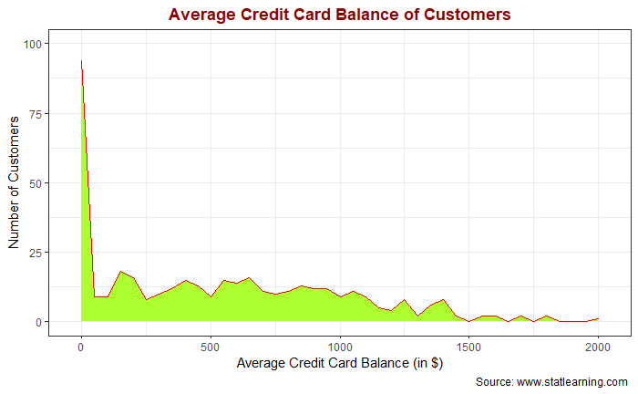

```r
ggplot(Credit, aes(Balance))+ #initializing the ggplot object and specifying the data as Credit and providing variable Balance
  geom_density(stat="bin",binwidth= 50, fill= "greenyellow",colour= "red" )+ #adding layer of density plot along with outline color and fill color. Also specifying bin and binwidths
  labs(x="Average Credit Card Balance (in $)", y="Number of Customers", title = "Average Credit Card Balance of Customers", caption = "Source: www.statlearning.com ")+ #specifying suitable texts for title,x nd y axis and caption
  coord_cartesian(ylim=c(0,100))+ #setting coordinates on y-axis
  theme_bw()+ # theme of the graph
  theme(plot.title = element_text(hjust = 0.5, face = "bold",color ="red4")) #justifying and editing the element text of plot title
```

```r
NA
```

### 1.2 Histogram Plot showing Number of Customers and their Income

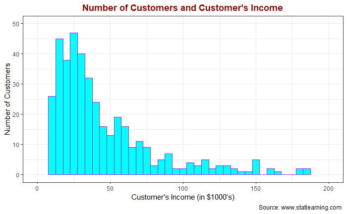

```r
ggplot(Credit, aes(Income))+ #initializing the ggplot object and specifying the data as Credit and providing variable Income
  geom_histogram(binwidth = 5, fill= "cyan",colour= "purple" )+ #adding layer of histogram plot along with outline color and fill color
  labs(x="Customer's Income (in $1000's)", y="Number of Customers", title = "Number of Customers and Customer's Income", caption = "Source: www.statlearning.com ")+ #specifying suitable texts for title,x nd y axes and caption
  coord_cartesian(xlim=c(0,200), ylim=c(0,50))+ #setting coordinates on x and y axis
  theme_bw()+ # theme of the graph
  theme(plot.title = element_text(hjust = 0.5, face = "bold",color ="red4")) #justifying and editing the element text of plot title
```

## 2. Two plots displaying information about a single categorical variable

### 2.1 Bar Plot displaying Customers and their Ethnicity

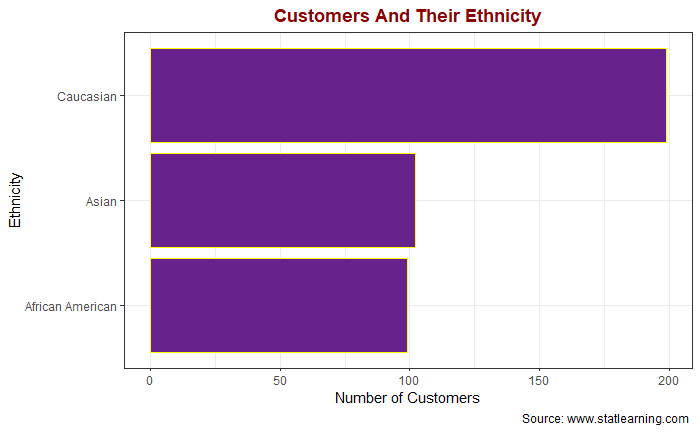

```r
ggplot(Credit, aes(Ethnicity, stat(count)))+ #initializing the ggplot object and specifying the data as Credit and providing variable Ethnicity and setting stat as total number of customers
  geom_bar(fill="darkorchid4", colour="yellow")+ #adding layer of bar plot along with outline color and fill color
  labs(x="Ethnicity", y="Number of Customers", title = "Customers And Their Ethnicity", caption = "Source: www.statlearning.com ")+ #specifying suitable texts for title,x nd y axis and caption
  coord_flip()+ #flipping axes for better visualization plot
  theme_bw()+ # theme of the graph
  theme(plot.title = element_text(hjust = 0.5, face = "bold",color ="red4")) #justifying and editing the element text of plot title
```

This Bar plot shows the number of customers from different ethnicity. The data shows that there are approximately 200 Caucasian customers, which is almost equal to the total number of customers from other two ethnicity (i.e Asian and African American) combined .

### 2.2 Bar Plot displaying proportion of Married vs Unmarried customers

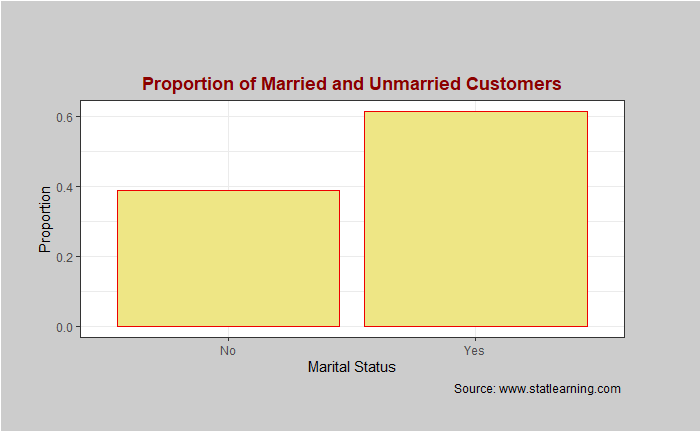

```r
ggplot(Credit, aes(Married, stat(prop), group=1))+ #initializing the ggplot object and specifying the data as Credit and providing variable Married and setting group=1 so that proportions are shown w.r.t. each other
  geom_bar(fill="khaki2", colour="red2")+ #adding layer of bar plot along with outline color and fill color
  labs(x="Marital Status", y="Proportion", title = "Proportion of Married and Unmarried Customers", caption = "Source: www.statlearning.com ")+ #specifying suitable texts for title,x nd y axis and caption
  theme_bw()+ #theme of the graph
  theme(plot.title = element_text(hjust = 0.5, face = "bold",color ="red4"))+ #justifying and editing the element text of plot title
  theme(plot.background=element_rect(fill="grey80"), plot.margin = unit(c(2, 2, 1, 1), "cm")) #modifying plot background and margins for better visualization
```

```r
NA
NA
```

The Bar plot represents the proportion of married and unmarried customers. From the plot it is clear that more than 60% of the customers are married while the rest 40% customers are Unmarried.

## 3. One plot displaying information about both a continuous variable and a categorical variable

### Box Plot represnting Average Credit Card Balance of Different Ethnicities

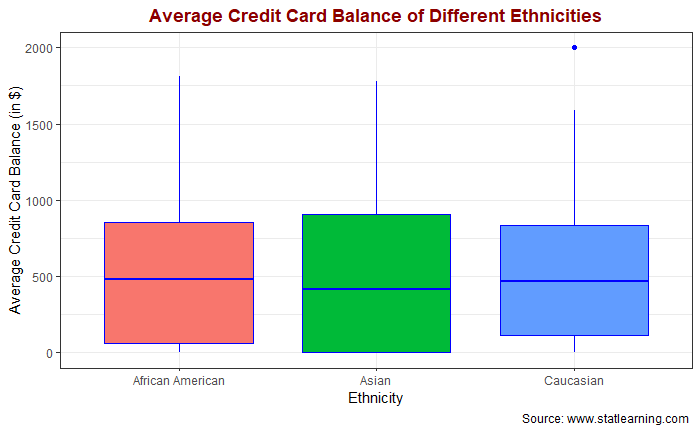

```r
ggplot(Credit, aes(x= Ethnicity, y= Balance, fill= Ethnicity))+ #initializing the ggplot object and specifying the data as Credit and providing variables Ethnicity and Balance, also adding fill color according to Ethnicity resulting in unique color for each ethnicity
  geom_boxplot(colour="blue")+ #adding layer of box plot along with color
  labs(x="Ethnicity", y="Average Credit Card Balance (in $)", title = "Average Credit Card Balance of Different Ethnicities", caption = "Source: www.statlearning.com ")+ #specifying suitable texts for title,x nd y axis and caption
  theme_bw()+ # theme of the graph
  theme(legend.position= "none")+ # removing legend for improved visualization as it doesn't serve much purpose
  theme(plot.title = element_text(hjust = 0.5, face = "bold",color ="red4")) #justifying and editing the element text of plot title
```

## 4. Two plots should display information that shows a relationship between two variables

### 4.1 Scatter Plot of Credit Card vs Credit Card Limit

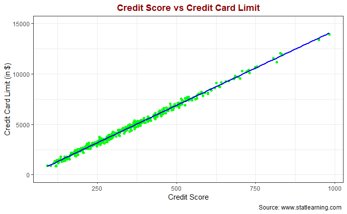

```r
ggplot(Credit,aes(x=Rating,y=Limit))+ #initializing the ggplot object and specifying the data as Credit and providing variables Rating to x and Limit to y
  geom_point(colour="green")+ #adding layer of scatter plot along with color
  geom_smooth(color="blue", method="lm", se= F)+ #adding another layer for representing trend in plot and providing type and color of the line
  labs(x="Credit Score", y="Credit Card Limit (in $)", title = "Credit Score vs Credit Card Limit", caption = "Source: www.statlearning.com ")+ #specifying suitable texts for title,x nd y axis and caption
  coord_cartesian(ylim=c(0,15000))+ #setting coordinates on y axis
  theme_bw()+ #theme of the graph
  theme(plot.title = element_text(hjust = 0.5, face = "bold",color ="red4")) #justifying and editing the element text of plot title
```

The Scatter Plot clearly shows that credit Score and Credit Card Limit are directly proportional to each other, i.e Credit Card Limit increases with increase in Credit Score. From plot, we can see that the highest Credit Card limit $13,913 is allocated to a customer having highest Credit score of 982.

### 4.2 Scatter Plot showing Relationship between Customer’s Income and Credit Score

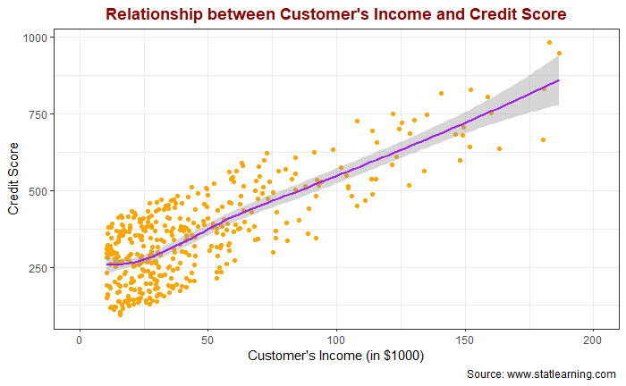

```r
ggplot(Credit,aes(x=Income,y=Rating))+ #initializing the ggplot object and specifying the data as Credit and providing variables Income and Rating
  geom_point(color='orange')+ #adding layer of scatter plot along with color
  geom_smooth(color="purple", method="loess")+ #adding another layer for representing trend in plot and providing type and color of the line
  labs(x="Customer's Income (in $1000)", y="Credit Score", title = "Relationship between Customer's Income and Credit Score", caption = "Source: www.statlearning.com ")+ #specifying suitable texts for title,x nd y axis and caption
  coord_cartesian(xlim=c(0,200))+ #setting coordinates on x axis
  theme_bw()+ #theme of the graph
  theme(plot.title = element_text(hjust = 0.5, face = "bold",color ="red4")) #justifying and editing the element text of plot title
```

```r
NA
```

Here the Customer’s Income is plotted against the Credit Score. The plot shows that the credit score gradually increases along with increase in customer’s income. This means that customer having higher income will get better credit score. From the plot, we can also see that credit score from 0 to 500 is most common for customers having Income between $10,000 to $50,000.

## 5. One plot should use faceting and display information about 4 variables

### Scatter Plot displaying infomartion about Income vs Credit Score by Ethnicity and Marital Status

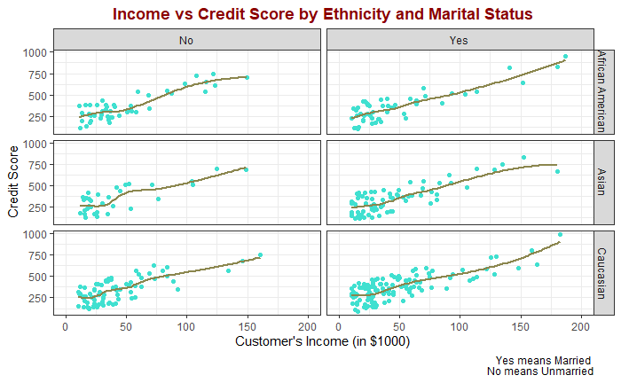

```r
ggplot(Credit,aes(x=Income,y=Rating))+ #initializing the ggplot object and specifying the data as Credit and providing variables Income to x and Rating to y
  geom_point(color='turquoise')+ #adding layer of scatter plot along with color
  geom_smooth(color="khaki4", method="loess", se = F)+ #adding another layer for representing trend in plot and providing type and color of the line
  facet_grid(Ethnicity~Married )+ #using facet grid will allow me to add two more variables
  coord_cartesian(xlim=c(0,200))+ #setting coordinates on x axis
  labs(x="Customer's Income (in $1000)", y="Credit Score", title = "Income vs Credit Score by Ethnicity and Marital Status", caption = "Yes means Married
       No means Unmarried")+ #specifying suitable texts for title,x nd y axis and caption
  theme_bw()+ # theme of the graph
  theme(plot.title = element_text(hjust = 0.5, face = "bold",color ="red4")) #justifying and editing the element text of plot title
```

## Questions

### 1. In what ways do you think data visualization is important to understanding a data set?

Data Visualization makes it easier to explore and understand relationship between multiple variables. Data visualization also helps in finding trends or patterns in any variable based on given data, which can be helpful in predicting future course of action. Instead of going through the whole dataset manually,we can use visualization get the key values of any variable instantly.

### 2. In what ways do you think data visualization is important to communicating important aspects of a data set?

A good visualization is self explanatory and conveys all the important aspects of a dataset in easy to understand manner. We can focus on important aspects by highlighting them in the plots with color, lines showing trend, different shapes, etc. Visualized data can also be appealing which makes the data presentation interesting.

### 3. What role does your integrity as an analyst play when creating a data visualization for communicating results to others?

As an analyst, it’s my responsibility to provide a data visualization which conveys correct information without any data manipulation. The visualization should be simple and easy to understand. It should contain all the important aspects but shouldn’t be crowded with information.

### 4. How many variables do you think you can successfully represent in a visualization? What happens when you exceed this number?

I can represent up-to 4 to 5 variables in a good visualization depending on the type of variables being used. It can be done by using faceting for 4 variables and using 5th variable as color. More than 5 variables are not preferable as it can make the visualization hard to understand and difficult to follow trends or patterns. The visualization looks clustered and untidy.

## References

http://r-statistics.co/Top50-Ggplot2-Visualizations-MasterList-R-Code.html

http://www.cookbook-r.com/Graphs/Scatterplots_(ggplot2)/

Both of these resources were very useful in the project. From selecting suitable plot for particular variables to how to modify the background, title, captions and axes of the plot. Going through multiple examples made it convenient to understand.